# Predicting 2019 CFB Games

2022-08-22

# What is this?

This page displays predictions for games in the 2019 CFB season. These predictions come from a model built on historical college football play by play and game data in order to simulate upcoming games. All data is from collegefootballdata.com.

# 1 Week 5 Predictions

| Season | Week | Quality | Home | Away | Pr(HomeWin) | Prediction | Result | Correct | correct |
| --- | --- | --- | --- | --- | --- | --- | --- | --- | --- |
| 2019 | 5 | 78 | Auburn | Mississippi State | 0.760 | Auburn by 10 |  |  |  |
| 2019 | 5 | 74 | Notre Dame | Virginia | 0.763 | Notre Dame by 11 |  |  |  |
| 2019 | 5 | 73 | Alabama | Ole Miss | 0.983 | Alabama by 34 |  |  |  |
| 2019 | 5 | 73 | Washington | USC | 0.705 | Washington by 9 |  |  |  |
| 2019 | 5 | 72 | Nebraska | Ohio State | 0.213 | Ohio State by 13 |  |  |  |
| 2019 | 5 | 71 | North Carolina | Clemson | 0.064 | Clemson by 25 |  |  |  |
| 2019 | 5 | 65 | Maryland | Penn State | 0.376 | Penn State by 6 |  |  |  |
| 2019 | 5 | 63 | Oklahoma | Texas Tech | 0.938 | Oklahoma by 27 |  |  |  |
| 2019 | 5 | 63 | Utah | Washington State | 0.639 | Utah by 6 |  |  |  |
| 2019 | 5 | 62 | Wisconsin | Northwestern | 0.823 | Wisconsin by 16 |  |  |  |

[output cut: 45 more lines]

# 2 Results Through Week 4

How has the model performed so far in 2019?

## 2.1 Assessment

The model predicts the probability that the home team will win and their expected margin of victory (or defeat). I assess the model’s performance by assessing the accuracy of its predictions (win/loss), the logloss of its probabilities, and the mean absolute error of the margin.

| Season | Week | N | Outcome Accuracy | Outcome LogLoss | Margin MAE |
| --- | --- | --- | --- | --- | --- |
| 2019 | 1 | 85 | 0.91 | 0.31 | 11.8 |
| 2019 | 2 | 74 | 0.84 | 0.35 | 13.9 |
| 2019 | 3 | 68 | 0.82 | 0.41 | 15.2 |
| 2019 | 4 | 58 | 0.76 | 0.47 | 12.1 |
| Season Average: |  |  | 0.84 | 0.38 | 13.2 |

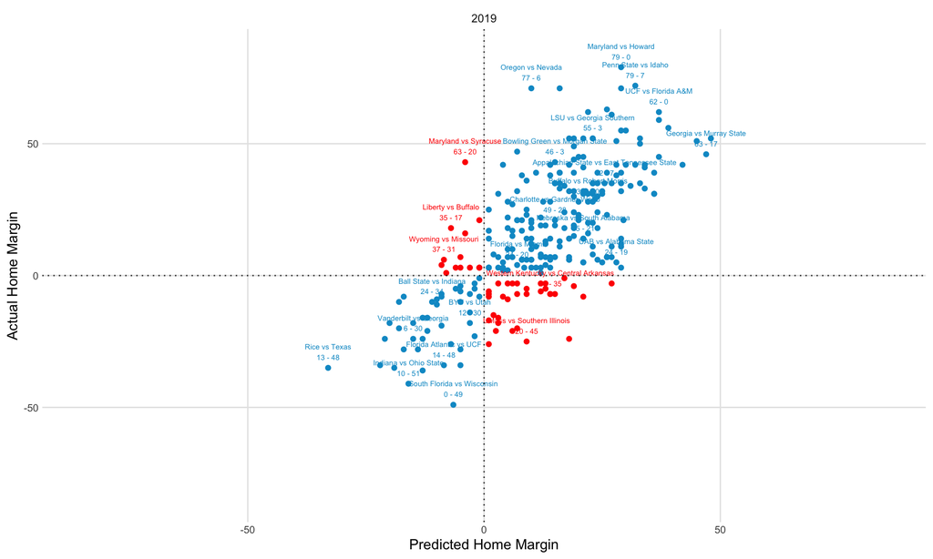

## 2.2 Results

The following table shows the results of games played in previous weeks next to the model’s predictions.

| Season | Week | Quality | Home | Away | Pr(HomeWin) | Prediction | Result | Correct | correct |
| --- | --- | --- | --- | --- | --- | --- | --- | --- | --- |
| 2019 | 4 | 89 | Georgia | Notre Dame | 0.733 | Georgia by 10 | Georgia by 6 | Yes | 1 |
| 2019 | 4 | 77 | Texas A&M | Auburn | 0.524 | Texas A&M by 1 | Auburn by 8 | No | 0 |
| 2019 | 4 | 72 | Wisconsin | Michigan | 0.495 | Michigan by 1 | Wisconsin by 21 | No | 0 |
| 2019 | 4 | 72 | Alabama | Southern Mississippi | 0.985 | Alabama by 34 | Alabama by 42 | Yes | 1 |
| 2019 | 4 | 69 | Texas | Oklahoma State | 0.699 | Texas by 9 | Texas by 6 | Yes | 1 |
| 2019 | 4 | 67 | USC | Utah | 0.560 | USC by 3 | USC by 7 | Yes | 1 |
| 2019 | 4 | 66 | Mississippi State | Kentucky | 0.658 | Mississippi State by 6 | Mississippi State by 15 | Yes | 1 |
| 2019 | 4 | 64 | Vanderbilt | LSU | 0.188 | LSU by 17 | LSU by 28 | Yes | 1 |
| 2019 | 4 | 63 | Pittsburgh | UCF | 0.359 | UCF by 8 | Pittsburgh by 1 | No | 0 |
| 2019 | 4 | 61 | Ohio State | Miami (OH) | 0.947 | Ohio State by 29 | Ohio State by 71 | Yes | 1 |

[output cut: 275 more lines]

# 3 Predicting the Rest of the Season

For example, we simulate the entire season before any games are played by simulating week two based on the (simulated) results of week one, then simulating week three based on the (simulated) results from week two. As a result, predictions for future weeks tend to be less accurate than predictions made one week in advance and are likely to change as we get closer to the actual game.

| Season | Week | Quality | Home | Away | Pr(HomeWin) | Prediction | Result | Correct | correct |
| --- | --- | --- | --- | --- | --- | --- | --- | --- | --- |
| 2019 | 5 | 78 | Auburn | Mississippi State | 0.760 | Auburn by 10 |  |  |  |
| 2019 | 5 | 74 | Notre Dame | Virginia | 0.763 | Notre Dame by 11 |  |  |  |
| 2019 | 5 | 73 | Alabama | Ole Miss | 0.983 | Alabama by 34 |  |  |  |
| 2019 | 5 | 73 | Washington | USC | 0.705 | Washington by 9 |  |  |  |
| 2019 | 5 | 72 | Nebraska | Ohio State | 0.213 | Ohio State by 13 |  |  |  |
| 2019 | 5 | 71 | North Carolina | Clemson | 0.064 | Clemson by 25 |  |  |  |
| 2019 | 5 | 65 | Maryland | Penn State | 0.376 | Penn State by 6 |  |  |  |
| 2019 | 5 | 63 | Oklahoma | Texas Tech | 0.938 | Oklahoma by 27 |  |  |  |
| 2019 | 5 | 63 | Utah | Washington State | 0.639 | Utah by 6 |  |  |  |
| 2019 | 5 | 62 | Wisconsin | Northwestern | 0.823 | Wisconsin by 16 |  |  |  |

[output cut: 546 more lines]